# Load, Split, and Balance

# Exceptional Work

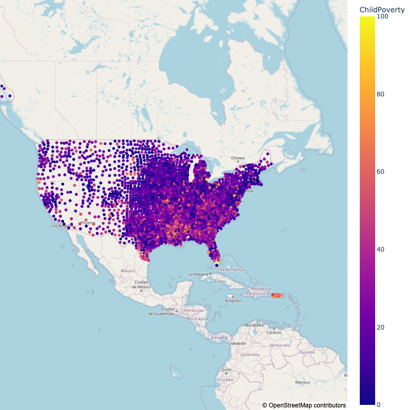

```python
import plotly.express as px
import plotly
fig = px.scatter_mapbox(distdf,
                        lat='latitude',
                        lon='longitude',
                        # hover_name="Address",
                        # hover_data=["Address", "Listed"],
                        color="ChildPoverty",
                        # color_continuous_scale=color_scale,
                        # size="Listed",
                        zoom=2.5,
                        height=800,
                        width=800)

fig.update_layout(mapbox_style="open-street-map")
fig.update_layout(margin={"r":0,"t":0,"l":0,"b":0})
fig.show(renderer="png")
# fig.write_html("ChildPoverty.html")
```

For our exceptional work, we plotted all of the provided counties on this map according to their percentage of child poverty. This is an interactive map where you can scroll around to explore different areas and it really provides a solid visualization of child poverty values based on longitude and latitude in the US. Using this, it is easier to see some patterns, such as the prevalence of child poverty in southern Florida, Puerto Rico, and parts of the Appalachian area.

```python
#Code to save location data.
# I just saved the out put of this code as csv, somethings it will hang up
# so might have to run it twice and save them all together.

get_lat_long = False
if get_lat_long:
    c=0
    latitude={}
    for i in county_unique:
        # c+=1
        # if c < 2563: continue
        i = i+',USA'
        if 'Municipio' in i: i = i.replace('Municipio',' ')
        if 'Census Area' in i: i= i.replace('Census Area',' ')
        if 'Borough' in i: i = i.replace('Borough',' ')
        location = geolocator.geocode(i)
        latitude[i] = (location.latitude, location.longitude)
        print((location.latitude, location.longitude),i)
```

```python
def look_up_lat(state,county):
    # print(row)
    i = county
    if 'Municipio' in i: i = i.replace('Municipio',' ')
    if 'Census Area' in i: i= i.replace('Census Area',' ')
    if 'Borough' in i: i = i.replace('Borough',' ')
    add = address_lookup[(address_lookup.State==state) & (address_lookup.County ==i) ]
    return add.latitude.item()

def look_up_long(state,county):
    # print(row)
    i = county
    if 'Municipio' in i: i = i.replace('Municipio',' ')
    if 'Census Area' in i: i= i.replace('Census Area',' ')
    if 'Borough' in i: i = i.replace('Borough',' ')
    add = address_lookup[(address_lookup.State==state) & (address_lookup.County ==i) ]
    return add.longitude.item()


latitude=  rawdf.apply(lambda row : look_up_lat(row.State,row.County),axis=1)
longitude=  rawdf.apply(lambda row : look_up_long(row.State,row.County),axis=1)
rawdf['latitude'],rawdf['longitude'] = latitude,longitude
```

```python
run_dist_calc = False
if run_dist_calc:
    distdf = deepcopy(rawdf)
    for lat1,long1,county,state in zip(rawdf.latitude,rawdf.longitude,rawdf.County,rawdf.State):
        d=[]
        if f'{county},{state}' in distdf.columns: continue
        print(f'{county},{state}')
        for lat2,long2 in zip(rawdf.latitude,rawdf.longitude):
            # print(distance.distance((lat1,long1), (lat2,long2)).miles)
            d.append(distance.distance((lat1,long1), (lat2,long2)).miles)
        # print(d)
        distdf[f'{county},{state}'] = d

        # assert False
```

```python
distdf.to_csv('acs2017_census_tract_data_modified_rel_dist.csv',index=False)
```

```python
#https://iopscience.iop.org/article/10.1088/1126-6708/2008/04/063/pdf
remove_list = []
c=0
Radius=10
save_class = {}
distdf1 = deepcopy(distdf)#.sample(n=10000,random_state=42)
while len([j for i in range(len(remove_list)) for j in remove_list[i]]) < len(distdf):
    Autauga1 = []
    c+=1
    df_group = deepcopy(distdf1)
    p= [j for i in range(len(remove_list)) for j in remove_list[i]]
    if c!=1:
        df_group = df_group.drop(p)

    # print(f"{c} Before",len(p),len(df_group))
    # print( df_group.index)

    for d, i in enumerate(df_group.index.values):

        if d ==0:   continue
        # print(f'i={i},c={c}')
        # print(distdf[i:i+1].County)
        # print(distdf[:1].County)
        # print(distdf[:1][f'{distdf[i:i+1].County.values[0]},{distdf[i:i+1].State.values[0]}'])
        dij = df_group[:1][f'{df_group[d:d+1].County.values[0]},{df_group[d:d+1].State.values[0]}'].values[0]
        kti = df_group[:1].ChildPoverty.values[0]
        ktj = df_group[d:d+1].ChildPoverty.values[0]
        # print(dij,kti,ktj)
        # print(' >',dij**2/max(kti**2,ktj**2))
        Autauga1.append(dij**2/max(kti**2,ktj**2))
    if len(Autauga1)!=0:
        Autauga1.insert(0,c)
    # print("Autauga1", len(Autauga1))
    if len(Autauga1)==0:
        break
    df_group['Autauga1'] = Autauga1


    # assert False
    df_group.loc[df_group['Autauga1'] <=Radius,f'group_{c}_'] = 1
    df_group.loc[df_group['Autauga1'] > Radius ,f'group_{c}_'] = 0
    # print(df_group[f'group_{c}_'])
    remove_list.append(list(df_group[df_group[f'group_{c}_']==1].index.values))

    save_class[f'group_{c}_'] = list(df_group[df_group[f'group_{c}_']==1].index.values)
    if c!=1:
        if len(save_class[f'group_{c}_'])==len(save_class[f'group_{c-1}_']):
            remove_list.append([df_group.index.values[0]])

    print(f"{c} After",len(p), len(df_group))
```